# Assignment 3

Ryan Johnson

9/22/2020

## Description

My data set includes six household level variables - four continuous, and two categorical (both with more than two levels). This data is from the 2018 ACS 1-year survey, filtered to include only those observations collected in Travis County, TX. These variables are:

1. **HINCP** (household annual income) - cont.
2. **RNTP** (monthly rent) - cont.
3. **NP** (number of people per household) - cont.
4. **BDSP** (number of bedrooms per household) - cont.
5. **HHT_2** (household type) - cat.
6. **BLDG_AGE_dec** (decade of building construction) - cat.

To search for relationships I will be conducting six correlation tests, one chi-square test, and 8 ANOVA tests between the various pairs of variables.

First I load the data, and mutate the **HHT** variable to create four levels from the original seven (by combining gender-differentiated levels), now known as **HHT_2**. This should make relationships strictly between household types (married couple families, single-parent families, non-family roommates, and single occupants), not genders, more clear.

```r
hh_data_a3 <- read.csv("TravisHH.csv") %>%
  mutate(HHT_2 = case_when(
    HHT_label=="Married couple household"~"Married couple",
    HHT_label=="Other family household: Female householder, no spouse present"~"Single parent family",
    HHT_label=="Other family household: Male householder, no spouse present"~"Single parent family",
    HHT_label=="Nonfamily household: Male householder: Not living alone"~"Non-family roommates",
    HHT_label=="Nonfamily household: Female householder: Not living alone"~"Non-family roommates",
    HHT_label=="Nonfamily household: Female householder: Living alone"~"Single occupant",
    HHT_label=="Nonfamily household: Male householder: Living alone"~"Single occupant"))
```

*As a note, I want to thank **Ana** for helping me correct the axes on my charts, and **Julia** for being the best motivator/GIF-sender a person could have!*

## Correlation tests

These Pearson correlation tests will explore the relationships and possible correlations between my continuous variables.

### Correlation one: HINCP and RNTP

Correlation test between annual household income and monthly rent.

```r
correlation1 <- cor.test(hh_data_a3$HINCP, hh_data_a3$RNTP)

correlation1
```

```
##
##  Pearson's product-moment correlation
##
## data:  hh_data_a3$HINCP and hh_data_a3$RNTP
## t = 25.705, df = 3796, p-value < 2.2e-16
## alternative hypothesis: true correlation is not equal to 0
## 95 percent confidence interval:
##  0.3576160 0.4118035
## sample estimates:
##       cor
## 0.3850416
```

Scatterplot of this correlation:

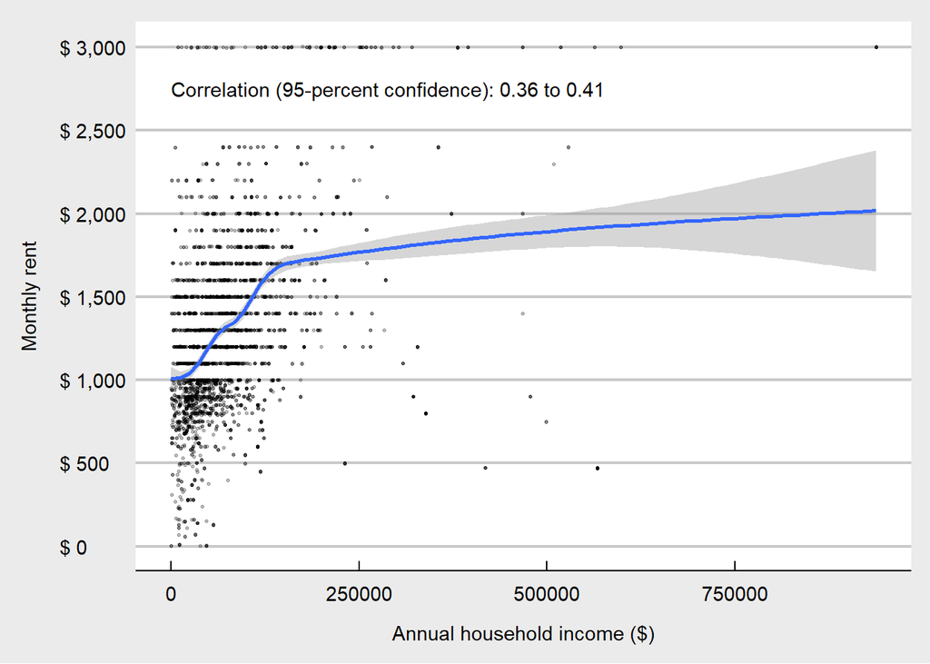

```r
ggplot(hh_data_a3, aes(x = HINCP, y = RNTP)) +
  geom_point(size = 0.5, alpha = 0.25, position = "jitter") +
  geom_smooth() +
  theme_economist_white() +
  scale_x_continuous(name = "\nAnnual household income ($)") +
  scale_y_continuous(name = "Monthly rent\n",
                     breaks = seq(0, 3000, by = 500),
                     labels = paste("$",
                                    prettyNum(seq(0, 3000, by = 500),
                                              big.mark = ","))) +
  annotate(geom = "text", x = 0, y = 2750,
           label = paste("Correlation (95-percent confidence):",
                         prettyNum(correlation1$conf.int[1], digits = 2),
                                    "to",
                                    prettyNum(correlation1$conf.int[2], digits = 2)),
                     hjust = 0)
```

### Correlation two: HINCP and NP

Correlation test between annual household income and household size (number of people per household).

```r
correlation2 <- cor.test(hh_data_a3$HINCP, hh_data_a3$NP)

correlation2
```

```
##
##  Pearson's product-moment correlation
##
## data:  hh_data_a3$HINCP and hh_data_a3$NP
## t = 16.694, df = 3796, p-value < 2.2e-16
## alternative hypothesis: true correlation is not equal to 0
## 95 percent confidence interval:
##  0.2316517 0.2909151
## sample estimates:
##       cor
## 0.2615299
```

Scatterplot of this correlation:

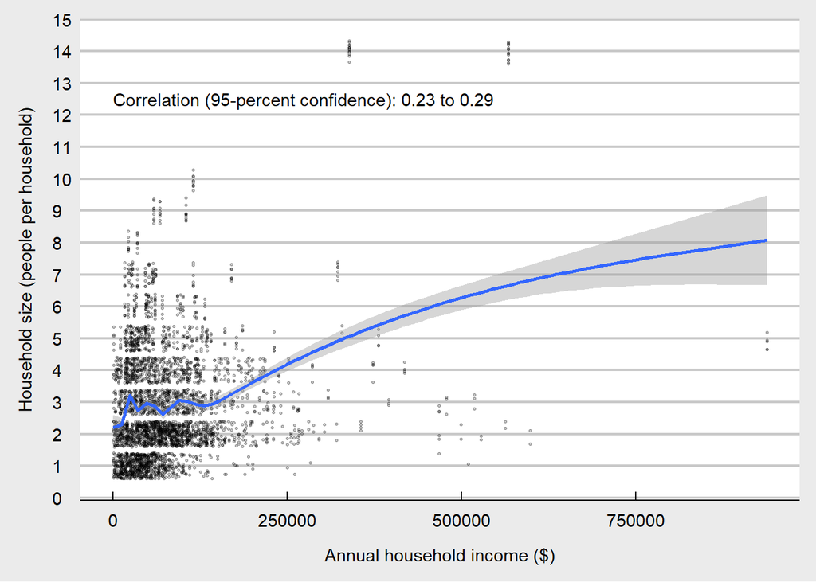

```r
ggplot(hh_data_a3, aes(x = HINCP, y = NP)) +
  geom_point(size = 0.5, alpha = 0.25, position = "jitter") +
  geom_smooth() +
  theme_economist_white() +
  scale_x_continuous(name = "\nAnnual household income ($)") +
  scale_y_continuous(name = "Household size (people per household)\n",
                     breaks = seq(0, 15, by = 1)) +
  annotate(geom = "text", x = 0, y = 12.5,
           label = paste("Correlation (95-percent confidence):",
                         prettyNum(correlation2$conf.int[1], digits = 2),
                                    "to",
                                    prettyNum(correlation2$conf.int[2], digits = 2)),
                     hjust = 0)
```

### Correlation three: HINCP and BDSP

Correlation test between annual household income and number of bedrooms per household.

```r
correlation3 <- cor.test(hh_data_a3$HINCP, hh_data_a3$BDSP)

correlation3
```

```
##
##  Pearson's product-moment correlation
##
## data:  hh_data_a3$HINCP and hh_data_a3$BDSP
## t = 16.818, df = 3796, p-value < 2.2e-16
## alternative hypothesis: true correlation is not equal to 0
## 95 percent confidence interval:
##  0.2334814 0.2926847
## sample estimates:
##      cor
## 0.263331
```

Scatterplot of this correlation:

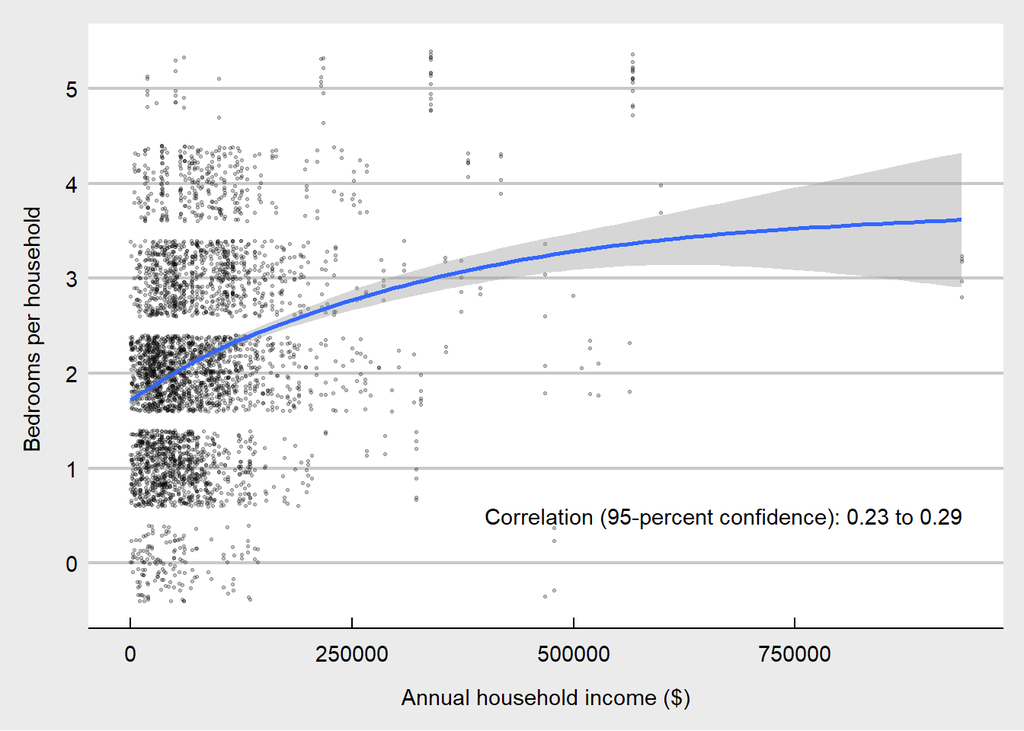

```r
ggplot(hh_data_a3, aes(x = HINCP, y = BDSP)) +
  geom_point(size = 0.5, alpha = 0.25, position = "jitter") +
  geom_smooth() +
  theme_economist_white() +
  scale_x_continuous(name = "\nAnnual household income ($)") +
  scale_y_continuous(name = "Bedrooms per household \n",
                     breaks = seq(0, 6, by = 1)) +
  annotate(geom = "text", x = 400000, y = 0.5,
           label = paste("Correlation (95-percent confidence):",
                         prettyNum(correlation3$conf.int[1], digits = 2),
                                    "to",
                                    prettyNum(correlation3$conf.int[2], digits = 2)),
                     hjust = 0)
```

### Correlation four: RNTP and NP

Correlation test between monthly rent and household size. In the following two correlations (#4 and #5), I chose to place monthly rent along the x-axis as this resulted in a much more legible visualization of the scatterplot and trend line.

```r
correlation4 <- cor.test(hh_data_a3$RNTP, hh_data_a3$NP)

correlation4
```

```
##
##  Pearson's product-moment correlation
##
## data:  hh_data_a3$RNTP and hh_data_a3$NP
## t = -3.5886, df = 3796, p-value = 0.0003367
## alternative hypothesis: true correlation is not equal to 0
## 95 percent confidence interval:
##  -0.0897857 -0.0263905
## sample estimates:
##         cor
## -0.05814672
```

Scatterplot of this correlation:

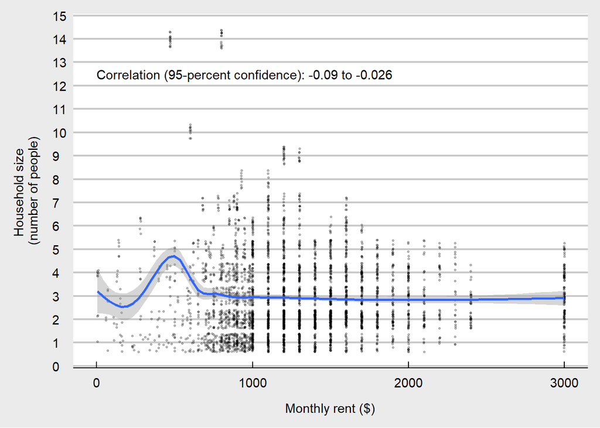

```r
ggplot(hh_data_a3, aes(x = RNTP, y = NP)) +
  geom_point(size = 0.5, alpha = 0.25, position = "jitter") +
  geom_smooth() +
  theme_economist_white() +
  scale_x_continuous(name = "\nMonthly rent ($)") +
  scale_y_continuous(name = "Household size \n(number of people)\n",
                     breaks = seq(0, 15, by = 1)) +
  annotate(geom = "text", x = 0, y = 12.5,
           label = paste("Correlation (95-percent confidence):",
                         prettyNum(correlation4$conf.int[1], digits = 2),
                                    "to",
                                    prettyNum(correlation4$conf.int[2], digits = 2)),
                     hjust = 0)
```

There is a very weak but statistically significant negative correlation between monthly rent and the size of a household. The correlation value is -0.058, with a p-value of ~0.0003.

### Correlation five: RNTP and BDSP

Correlation test between monthly rent and number of bedrooms per household.

```r
correlation5 <- cor.test(hh_data_a3$RNTP, hh_data_a3$BDSP)

correlation5
```

```
##
##  Pearson's product-moment correlation
##
## data:  hh_data_a3$RNTP and hh_data_a3$BDSP
## t = 20.107, df = 3796, p-value < 2.2e-16
## alternative hypothesis: true correlation is not equal to 0
## 95 percent confidence interval:
##  0.2812128 0.3387059
## sample estimates:
##      cor
## 0.310243
```

Scatterplot of this correlation:

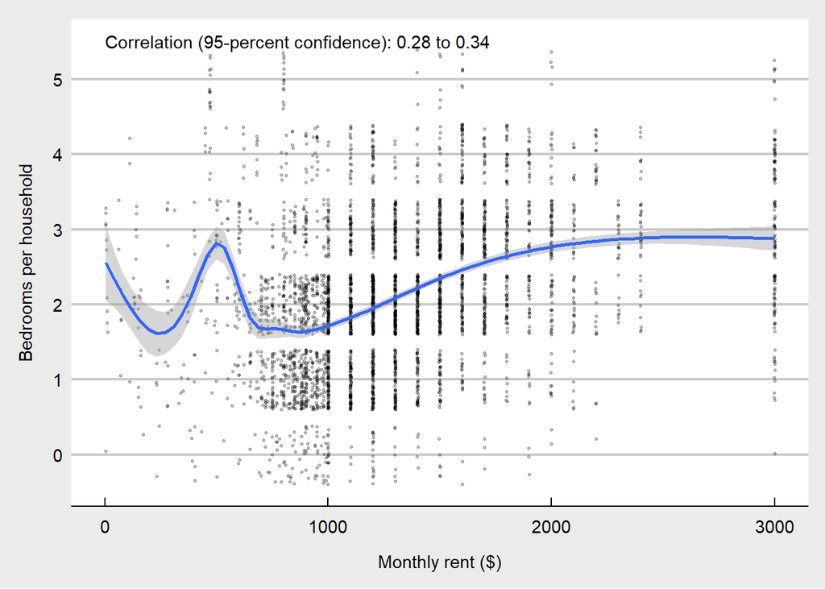

```r
ggplot(hh_data_a3, aes(x = RNTP, y = BDSP)) +
  geom_point(size = 0.5, alpha = 0.25, position = "jitter") +
  geom_smooth() +
  theme_economist_white() +
  scale_x_continuous(name = "\nMonthly rent ($)") +
  scale_y_continuous(name = "Bedrooms per household\n",
                     breaks = seq(0, 5, by = 1)) +
  annotate(geom = "text", x = 0, y = 5.5,
           label = paste("Correlation (95-percent confidence):",
                         prettyNum(correlation5$conf.int[1], digits = 2),
                                    "to",
                                    prettyNum(correlation5$conf.int[2], digits = 2)),
                     hjust = 0)
```

### Correlation six: NP and BDSP

Correlation test between household size and the number of bedrooms per household.

```r
correlation6 <- cor.test(hh_data_a3$NP, hh_data_a3$BDSP)

correlation6
```

```
##
##  Pearson's product-moment correlation
##
## data:  hh_data_a3$NP and hh_data_a3$BDSP
## t = 39.145, df = 3796, p-value < 2.2e-16
## alternative hypothesis: true correlation is not equal to 0
## 95 percent confidence interval:
##  0.5132105 0.5585409
## sample estimates:
##       cor
## 0.5362622
```

Scatterplot of this correlation:

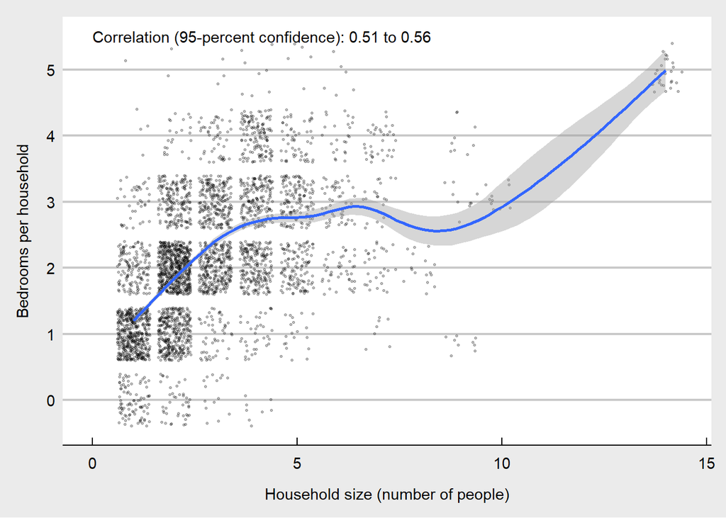

```r
ggplot(hh_data_a3, aes(x = NP, y = BDSP)) +
  geom_point(size = 0.5, alpha = 0.25, position = "jitter") +
  geom_smooth() +
  theme_economist_white() +
  scale_x_continuous(name = "\nHousehold size (number of people)") +
  scale_y_continuous(name = "Bedrooms per household\n",
                     breaks = seq(0, 6, by = 1)) +
  annotate(geom = "text", x = 0, y = 5.5,
           label = paste("Correlation (95-percent confidence):",
                         prettyNum(correlation6$conf.int[1], digits = 2),
                                    "to",
                                    prettyNum(correlation6$conf.int[2], digits = 2)),
                     hjust = 0)
```

## Chi-square test

The Chi-square test will explore the potential relationship between the two categorical variables in my dataset, the decade of construction (BLDG_AGE_dec) and the household type (HHT_2).

### Chi-square test one: BLD_AGE_dec and HHT_2

Association between decade of construction and household type.

```r
chi_sq <- chisq.test(hh_data_a3$BLDG_AGE_dec, hh_data_a3$HHT_2)

chi_sq
```

```
##
##  Pearson's Chi-squared test
##
## data:  hh_data_a3$BLDG_AGE_dec and hh_data_a3$HHT_2
## X-squared = 124.93, df = 24, p-value = 1.273e-15
```

With a p-value of 1.273e-15, the relationship is statistically significant at a 95-percent confidence level.

```r
chi_sq$observed
```

```
##                        hh_data_a3$HHT_2
## hh_data_a3$BLDG_AGE_dec Married couple Non-family roommates Single occupant
##               1940s                  9                   24               8
##               1950s                 50                   40              17
##               1960s                 98                   86              58
##               1970s                240                  135             128
##               1980s                286                  163             153
##               1990s                219                  152             111
##               2000s                242                  126             115
##               2010s                169                  148             150
##               pre-1940s             39                   35              11
##                        hh_data_a3$HHT_2
## hh_data_a3$BLDG_AGE_dec Single parent family
##               1940s                       14
##               1950s                       43
##               1960s                       24
##               1970s                      137
##               1980s                      187
##               1990s                      160
##               2000s                      132
##               2010s                       80
##               pre-1940s                    9
```

```r
chi_sq$expected
```

```
##                        hh_data_a3$HHT_2
## hh_data_a3$BLDG_AGE_dec Married couple Non-family roommates Single occupant
##               1940s           19.57873             13.16351        10.87546
##               1950s           53.39652             35.90047        29.66035
##               1960s           94.68984             63.66351        52.59768
##               1970s          227.82517            153.17536       126.55082
##               1980s          280.86572            188.83649       156.01343
##               1990s          228.53712            153.65403       126.94629
##               2000s          218.92575            147.19194       121.60742
##               2010s          194.71933            130.91706       108.16140
##               pre-1940s       33.46182             22.49763        18.58715
##                        hh_data_a3$HHT_2
## hh_data_a3$BLDG_AGE_dec Single parent family
##               1940s                 11.38231
##               1950s                 31.04265
##               1960s                 55.04897
##               1970s                132.44866
##               1980s                163.28436
##               1990s                132.86256
##               2000s                127.27488
##               2010s                113.20221
##               pre-1940s             19.45340
```

Coming up with a way to visualize these results was a challenge, but I believe that a heatmap is an elegant and fairly powerful way to do so. I toyed with a few different methods for creating a heatmap before coming to the following solution.

I took the difference between observed and expected values from the chi-squared test, and used the results to define a new data frame **C_diff_data**. I then plot this data frame as a heatmap, with one variable on each axis and the magnitude of difference as the fill, to visualize the distribution of households by age of construction and household type.

```r
C_diff <- chi_sq$observed - chi_sq$expected

C_diff_data <- as.data.frame(C_diff)
```

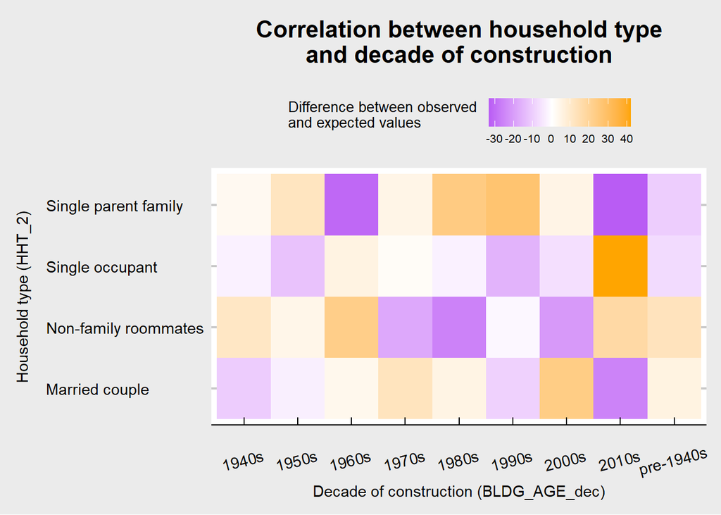

```r
C_diff_heatmap <- ggplot(C_diff_data,
       aes(x = hh_data_a3.BLDG_AGE_dec,
           y = hh_data_a3.HHT_2,
           fill = Freq)) +
  geom_tile() +
  scale_x_discrete(name = "\nDecade of construction (BLDG_AGE_dec)") +
  scale_y_discrete(name = "Household type (HHT_2)\n") +
  theme_economist_white() +
  theme(legend.key.size =  unit(0.7, "cm"),
        plot.title = element_text(hjust = 0.5),
        axis.text.x = element_text(angle = 15),
        legend.text = element_text(size = 8),
        legend.title = element_text(size = 10)) +
  scale_fill_gradient2(name = "Difference between observed \nand expected values\n",
                       midpoint=0,
                       low="purple",
                       mid="white",
                       high="orange",
                       space ="Lab",
                       breaks = seq(-30, 40, by = 10),
                       labels = seq(-30, 40, by = 10)) +
  ggtitle(label = "Correlation between household type\nand decade of construction\n")

C_diff_heatmap
```

The resulting chart highlights that single occupant households are *over-represented* (orange values) in housing built in the 2010s, while single-parent family households are *under-represented* (purple values) in housing built in the 1960s and 2010s, among other less-distinct differences.

## Analysis of variance (ANOVA) tests

The ANOVA tests will explore the potential relationship between each categorical variable and the continuous variables in my dataset. In total, I will run eight ANOVA tests - four between household type and the continuous variables, and four between decade of construction and the continuous variables.

### ANOVA test one: HINCP and HHT_2

Test of relationship between annual household income and household type.

```r
anova1 <- aov(HINCP ~ HHT_2, data = hh_data_a3)

summary(anova1)
```

```
##               Df    Sum Sq   Mean Sq F value Pr(>F)
## HHT_2          3 1.399e+12 4.663e+11    73.8 <2e-16 ***
## Residuals   3794 2.398e+13 6.319e+09
## ---
## Signif. codes:  0 '***' 0.001 '**' 0.01 '*' 0.05 '.' 0.1 ' ' 1
```

As indicated by the significance code and low p-value (<2e-16), there is a statistically significant relationship between annual household income and household type. The magnitude of the associations between each category can be seen by conducting a Tukey’s Honestly Significant Difference test and visualizing the data on a box plot.

```r
differences1 <- TukeyHSD(anova1)

as_tibble(cbind(pair = row.names(differences1$HHT_2),
                differences1$HHT_2))
```

```
## # A tibble: 6 x 5
##   pair                      diff         lwr          upr         `p adj`
##   <chr>                     <chr>        <chr>        <chr>       <chr>
## 1 Non-family roommates-Mar~ -12.6300196~ -8776.09894~ 8750.83890~ 0.99999998174~
## 2 Single occupant-Married ~ -47144.7687~ -56443.1506~ -37846.386~ 1.40092615286~
## 3 Single parent family-Mar~ -27079.0885~ -36243.4094~ -17914.767~ 1.40095191003~
## 4 Single occupant-Non-fami~ -47132.1386~ -57207.2114~ -37057.065~ 1.40092615286~
## 5 Single parent family-Non~ -27066.4584~ -37017.9389~ -17114.978~ 1.40286267047~
## 6 Single parent family-Sin~ 20065.68019~ 9640.063598~ 30491.2967~ 4.70909934457~
```

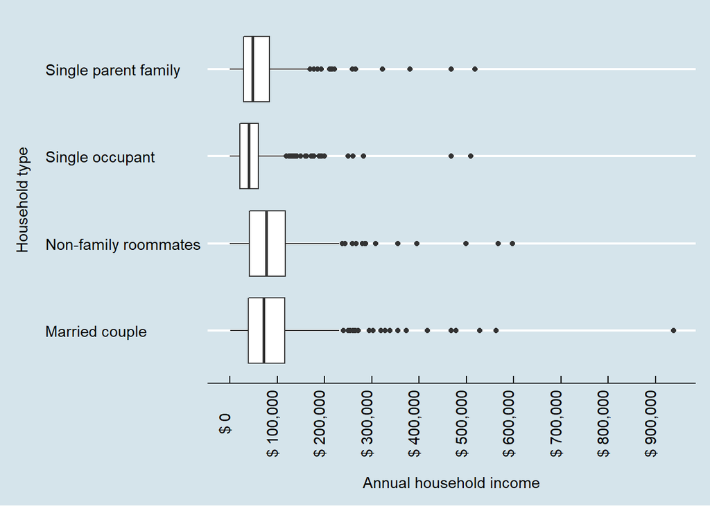

```r
options(scipen = 999)
ggplot(hh_data_a3, aes(x = HHT_2, y = HINCP)) +
  geom_boxplot() +
  theme_economist() +
  theme(axis.text.x = element_text(angle = 90)) +
  scale_x_discrete(name = "Household type\n") +
  scale_y_continuous(name = "\nAnnual household income",
                     breaks = seq(0, 1000000, by = 100000),
                     labels = paste("$",
                                    prettyNum(seq(0, 1000000, by = 100000),
                                              big.mark = ","))) +
  coord_flip()
```

We see that married couple households and non-family roommate households see a higher annual income that single occupant and single parent family households.

### ANOVA test two: RNTP and HHT_2

Test of relationship between monthly rent and household type.

```r
anova2 <- aov(RNTP ~ HHT_2, data = hh_data_a3)

summary(anova2)
```

```
##               Df     Sum Sq  Mean Sq F value              Pr(>F)
## HHT_2          3   46015920 15338640   56.42 <0.0000000000000002 ***
## Residuals   3794 1031431379   271859
## ---
## Signif. codes:  0 '***' 0.001 '**' 0.01 '*' 0.05 '.' 0.1 ' ' 1
```

Again, as indicated by the significance code and low p-value (<2e-16), there is a statistically significant relationship between monthly rent and household type. I will again conduct a Tukey’s HSD test and visualize the data on a box plot.

```r
differences2 <- TukeyHSD(anova2)

as_tibble(cbind(pair = row.names(differences2$HHT_2),
                differences2$HHT_2))
```

```
## # A tibble: 6 x 5
##   pair                      diff         lwr         upr         `p adj`
##   <chr>                     <chr>        <chr>       <chr>       <chr>
## 1 Non-family roommates-Mar~ 63.89563438~ 6.41607111~ 121.375197~ 0.022323020662~
## 2 Single occupant-Married ~ -231.859455~ -292.84751~ -170.87139~ 0.000000014009~
## 3 Single parent family-Mar~ -139.878280~ -199.98703~ -79.769530~ 0.000000028532~
## 4 Single occupant-Non-fami~ -295.755090~ -361.83745~ -229.67272~ 0.000000014009~
## 5 Single parent family-Non~ -203.773914~ -269.04564~ -138.50218~ 0.000000014009~
## 6 Single parent family-Sin~ 91.98117522~ 23.5995909~ 160.362759~ 0.003096615569~
```

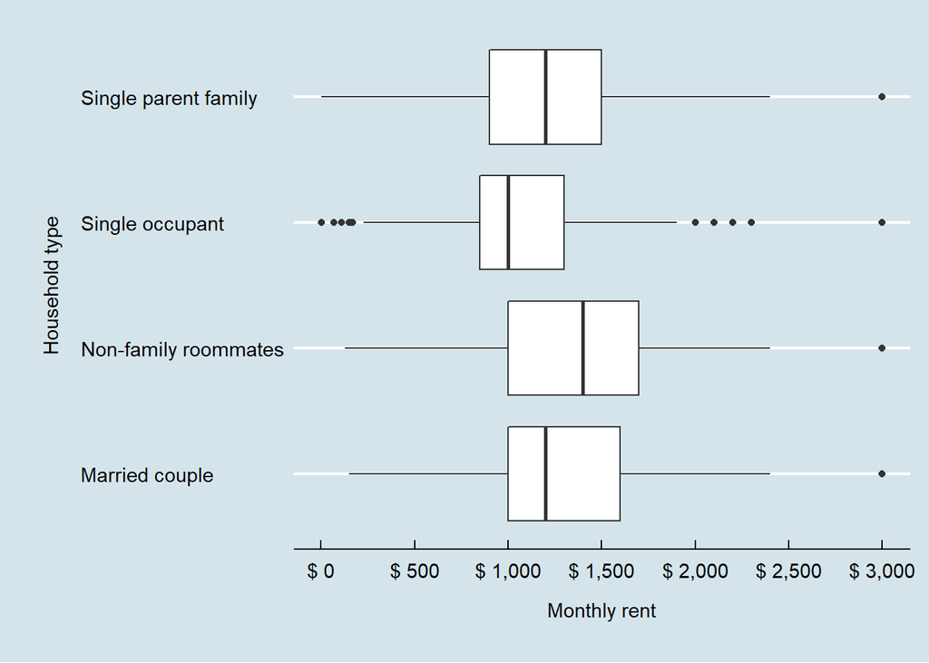

```r
options(scipen = 999)
ggplot(hh_data_a3, aes(x = HHT_2, y = RNTP)) +
  geom_boxplot() +
  theme_economist() +
  theme(axis.text.x = element_text(angle = 0)) +
  scale_x_discrete(name = "\nHousehold type\n") +
  scale_y_continuous(name = "\nMonthly rent\n",
                     breaks = seq(0, 3000, by = 500),
                     labels = paste("$",
                                    prettyNum(seq(0, 3000, by = 500),
                                              big.mark = ","))) +
  coord_flip()
```

We see that non-family roommate households on average pay higher monthly rents than all other household types, but also have the widest interquartile range of all household types. Single-occupant households pay the lowest average monthly rent by a small margin.

### ANOVA test three: NP and HHT_2

Test of relationship between household size and household type.

```r
anova3 <- aov(NP ~ HHT_2, data = hh_data_a3)

summary(anova3)
```

```
##               Df Sum Sq Mean Sq F value              Pr(>F)
## HHT_2          3   4379  1459.8   581.1 <0.0000000000000002 ***
## Residuals   3794   9531     2.5
## ---
## Signif. codes:  0 '***' 0.001 '**' 0.01 '*' 0.05 '.' 0.1 ' ' 1
```

Once more we see a very low p-value (<2e-16), indicating that there is a statistically significant relationship between household size and household type. I will again conduct a Tukey’s HSD test and visualize the data on a box plot.

```r
differences3 <- TukeyHSD(anova3)

as_tibble(cbind(pair = row.names(differences3$HHT_2),
                differences3$HHT_2))
```

```
## # A tibble: 6 x 5
##   pair                     diff         lwr          upr         `p adj`
##   <chr>                    <chr>        <chr>        <chr>       <chr>
## 1 Non-family roommates-Ma~ -1.13722895~ -1.31195651~ -0.9625014~ 0.000000014009~
## 2 Single occupant-Married~ -2.83579881~ -3.02119155~ -2.6504060~ 0.000000014009~
## 3 Single parent family-Ma~ -0.16658762~ -0.34930742~ 0.01613218~ 0.088620458603~
## 4 Single occupant-Non-fam~ -1.69856985~ -1.89944839~ -1.4976913~ 0.000000014009~
## 5 Single parent family-No~ 0.970641338~ 0.772227007~ 1.16905567~ 0.000000014009~
## 6 Single parent family-Si~ 2.669211195~ 2.461343456~ 2.87707893~ 0.000000014009~
```

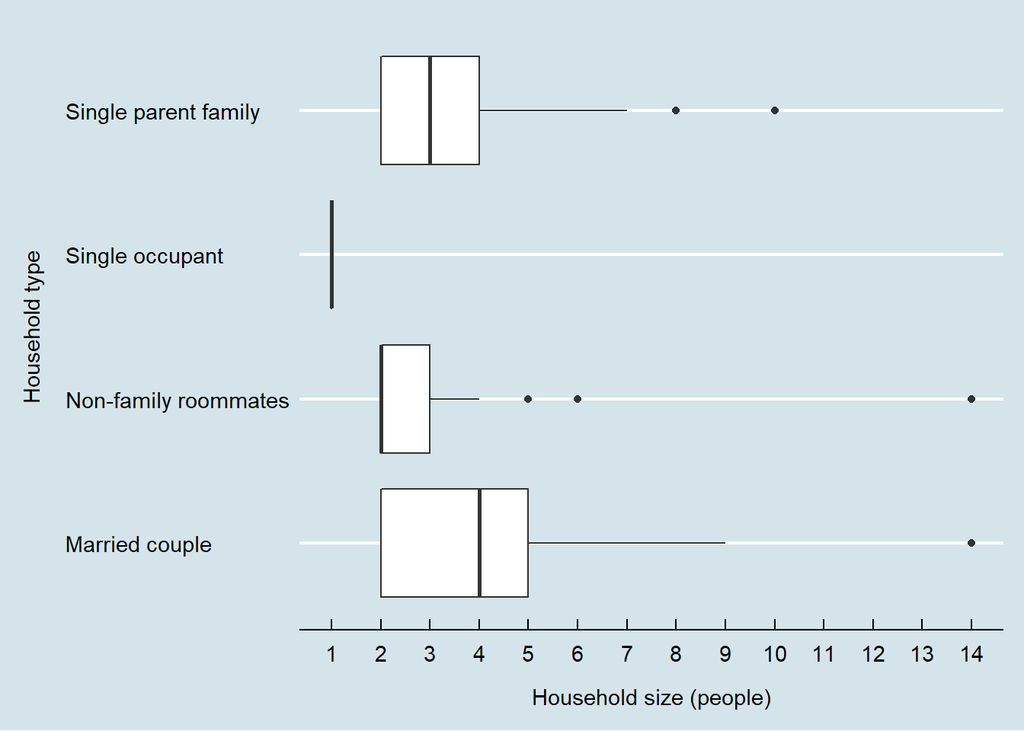

```r
ggplot(hh_data_a3, aes(x = HHT_2, y = NP)) +
  geom_boxplot() +
  theme_economist() +
  theme(axis.text.x = element_text(angle = 0)) +
  scale_x_discrete(name = "Household type\n") +
  scale_y_continuous(name = "\nHousehold size (people)",
                     breaks = seq(0, 15, by = 1),
                     labels = paste(prettyNum(seq(0, 15, by = 1)))) +
  coord_flip()
```

This box plot shows that the median married couple household has more members (4) than other household types, but also that married couple households have the widest interquartile range of all household types (between 2 and 5). Single-occupant households, by definition, contain only one member.

### ANOVA test four: BDSP and HHT_2

Test of relationship between the number of bedrooms per household and household type.

```r
anova4 <- aov(BDSP ~ HHT_2, data = hh_data_a3)

summary(anova4)
```

```
##               Df Sum Sq Mean Sq F value              Pr(>F)
## HHT_2          3    795  265.02   297.7 <0.0000000000000002 ***
## Residuals   3794   3378    0.89
## ---
## Signif. codes:  0 '***' 0.001 '**' 0.01 '*' 0.05 '.' 0.1 ' ' 1
```

Again, the very low p-value (<2e-16) indicates that there is a statistically significant relationship between number of bedrooms in a household, and household type. I will conduct a Tukey’s HSD test and visualize the data on a box plot.

```r
differences4 <- TukeyHSD(anova4)

as_tibble(cbind(pair = row.names(differences4$HHT_2),
                differences4$HHT_2))
```

```
## # A tibble: 6 x 5
##   pair                    diff         lwr          upr          `p adj`
##   <chr>                   <chr>        <chr>        <chr>        <chr>
## 1 Non-family roommates-M~ -0.10570250~ -0.20972081~ -0.00168420~ 0.044733939557~
## 2 Single occupant-Marrie~ -1.16032568~ -1.27069315~ -1.04995820~ 0.000000014009~
## 3 Single parent family-M~ 0.047124606~ -0.06165162~ 0.155900836~ 0.6812447701333
## 4 Single occupant-Non-fa~ -1.05462317~ -1.17420960~ -0.93503674~ 0.000000014009~
## 5 Single parent family-N~ 0.152827114~ 0.034707667~ 0.270946562~ 0.004937366820~
## 6 Single parent family-S~ 1.207450286~ 1.083703063~ 1.331197510~ 0.000000014009~
```

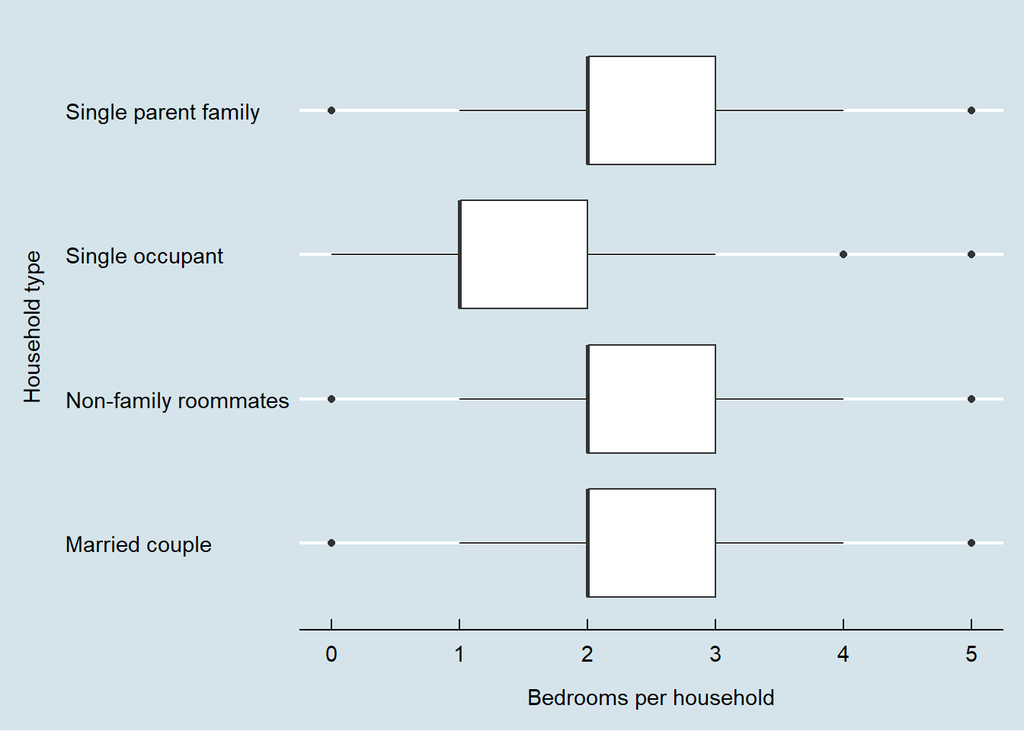

```r
ggplot(hh_data_a3, aes(x = HHT_2, y = BDSP)) +
  geom_boxplot() +
  theme_economist() +
  theme(axis.text.x = element_text(angle = 0)) +
  scale_x_discrete(name = "Household type\n") +
  scale_y_continuous(name = "\nBedrooms per household",
                     breaks = seq(0, 6, by = 1),
                     labels = paste(prettyNum(seq(0, 6, by = 1)))) +
  coord_flip()
```

This box plot does a great job of qualifying the relationship between these variables. Every household type besides single occupant households has an interquartile range of 1, and a median value of two bedrooms. Single-occupant households have an interquartile range *and* a median value of 1. While the relationship between bedrooms and household size is statistically significant, it is not particularly telling.

### ANOVA test five: HINCP and BLDG_AGE_dec

Test of relationship between annual household income and decade of construction.

```r
anova5 <- aov(HINCP ~ BLDG_AGE_dec, data = hh_data_a3)

summary(anova5)
```

```
##                Df         Sum Sq     Mean Sq F value              Pr(>F)
## BLDG_AGE_dec    8   759448745473 94931093184   14.61 <0.0000000000000002 ***
## Residuals    3789 24614973006420  6496429930
## ---
## Signif. codes:  0 '***' 0.001 '**' 0.01 '*' 0.05 '.' 0.1 ' ' 1
```

In this test we see a very low p-value (<2e-16), indicating that there is a statistically significant relationship between annual household income and the decade of building construction. I will conduct a Tukey’s HSD test and visualize the data on a box plot.

```r
differences5 <- TukeyHSD(anova5)

as_tibble(cbind(pair = row.names(differences5$BLDG_AGE_dec),
                differences5$BLDG_AGE_dec))
```

```
## # A tibble: 36 x 5
##    pair           diff            lwr             upr            `p adj`
##    <chr>          <chr>           <chr>           <chr>          <chr>
##  1 1950s-1940s    -7.27878787909~ -39438.8503382~ 39424.2927624~ 1
##  2 1960s-1940s    -5628.23718386~ -42681.3316076~ 31424.8572399~ 0.999937063971~
##  3 1970s-1940s    -10083.4985795~ -45232.6788081~ 25065.6816490~ 0.993506484715~
##  4 1980s-1940s    -15711.8686484~ -50597.4132346~ 19173.6759376~ 0.899009586819~
##  5 1990s-1940s    -3924.62956669~ -39069.4768338~ 31220.2177004~ 0.999994167963~
##  6 2000s-1940s    24039.69844789~ -11165.9727632~ 59245.3696590~ 0.460140807206~
##  7 2010s-1940s    14450.49293667~ -20934.3577816~ 49835.3436550~ 0.940671092332~
##  8 pre-1940s-194~ -11325.8007736~ -53791.8630870~ 31140.2615396~ 0.996060501989~
##  9 1960s-1950s    -5620.95839599~ -31162.9258689~ 19921.0090769~ 0.998994686749~
## 10 1970s-1950s    -10076.2197916~ -32768.1823941~ 12615.7428107~ 0.906243114653~
## # ... with 26 more rows
```

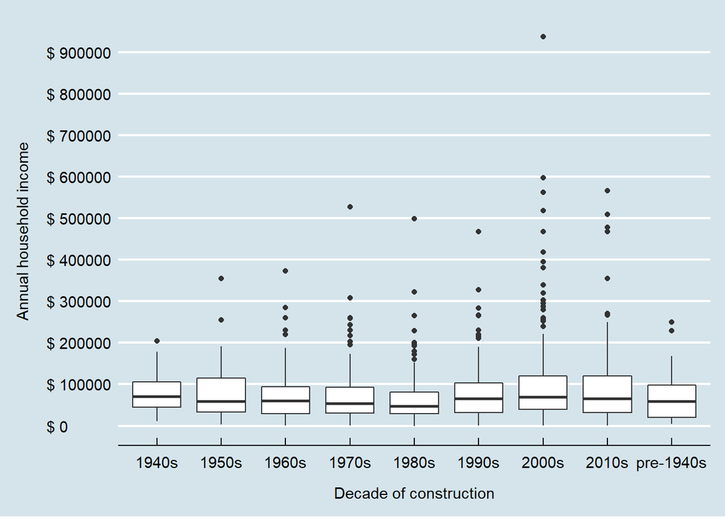

```r
options(scipen = 999)
ggplot(hh_data_a3, aes(x = BLDG_AGE_dec, y = HINCP)) +
  geom_boxplot() +
  theme_economist() +
  theme(axis.text.x = element_text(angle = 0)) +
  scale_x_discrete(name = "\nDecade of construction") +
  scale_y_continuous(name = "Annual household income\n",
                     breaks = seq(0, 1000000, by = 100000),
                     labels = paste("$",
                                    prettyNum(seq(0, 1000000, by = 100000))))
```

Same as above, but with household incomes plotted on a logarithmic scale:

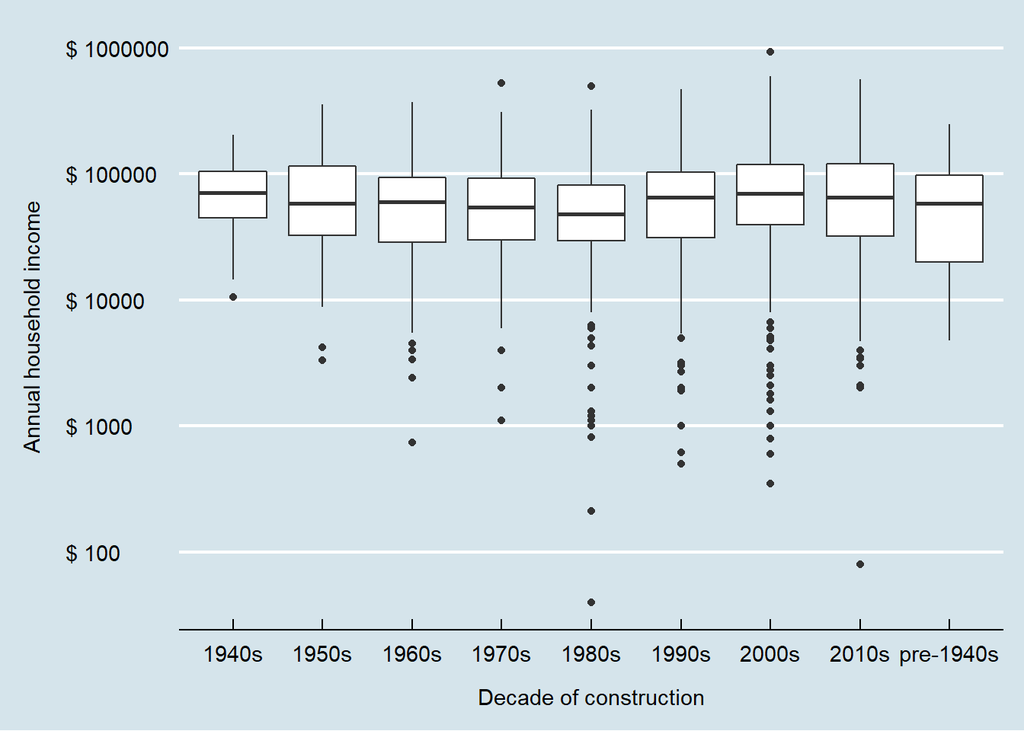

```r
options(scipen = 999)
ggplot(hh_data_a3, aes(x = BLDG_AGE_dec, y = HINCP)) +
  geom_boxplot() +
  theme_economist() +
  theme(axis.text.x = element_text(angle = 0)) +
  scale_x_discrete(name = "\nDecade of construction") +
  scale_y_log10(name = "Annual household income\n",
                     breaks = c(0, 100, 1000, 10000, 100000, 1000000),
                     labels = paste("$",
                                    prettyNum(c(0, 100, 1000, 10000, 100000, 1000000))))
```

The two box plots above together show the trend of variation among household incomes by building age. Generally, as building age decreases, household incomes rise, but we do see a local peak in incomes in 1940s- and 1950s-built households, followed by a drop to the lowest median incomes in 1980s-built households.

### ANOVA test six: RNTP and BLDG_AGE_dec

Test of relationship between monthly rent and decade of construction.

```r
anova6 <- aov(RNTP ~ BLDG_AGE_dec, data = hh_data_a3)

summary(anova6)
```

```
##                Df     Sum Sq Mean Sq F value              Pr(>F)
## BLDG_AGE_dec    8   57444785 7180598   26.67 <0.0000000000000002 ***
## Residuals    3789 1020002514  269201
## ---
## Signif. codes:  0 '***' 0.001 '**' 0.01 '*' 0.05 '.' 0.1 ' ' 1
```

Yet again, a very low p-value (<2e-16), indicating that there is a statistically significant relationship between monthly rent and the decade of building construction. I will conduct another Tukey’s HSD test and visualize the data on a box plot.

```r
differences6 <- TukeyHSD(anova6)

as_tibble(cbind(pair = row.names(differences6$BLDG_AGE_dec),
                differences6$BLDG_AGE_dec))
```

```
## # A tibble: 36 x 5
##    pair          diff           lwr            upr            `p adj`
##    <chr>         <chr>          <chr>          <chr>          <chr>
##  1 1950s-1940s   -126.30303030~ -380.13424340~ 127.528182799~ 0.834458071396917
##  2 1960s-1940s   -346.36568694~ -584.88602831~ -107.84534557~ 0.000233311664644~
##  3 1970s-1940s   -394.46448863~ -620.72884245~ -168.20013481~ 0.000002392200714~
##  4 1980s-1940s   -420.84295425~ -645.41021733~ -196.27569117~ 0.000000247581545~
##  5 1990s-1940s   -300.50240725~ -526.73886867~ -74.265945821~ 0.001270401724924~
##  6 2000s-1940s   -152.95994087~ -379.58794174~ 73.6680599976~ 0.477046734509243
##  7 2010s-1940s   -118.90510221~ -346.68652785~ 108.876323437~ 0.793987637333937
##  8 pre-1940s-19~ -297.61508704~ -570.98010113~ -24.250072945~ 0.0210066201096081
##  9 1960s-1950s   -220.06265664~ -384.48289995~ -55.642413324~ 0.001112370933232~
## 10 1970s-1950s   -268.16145833~ -414.23548400~ -122.08743265~ 0.000000482381048~
## # ... with 26 more rows
```

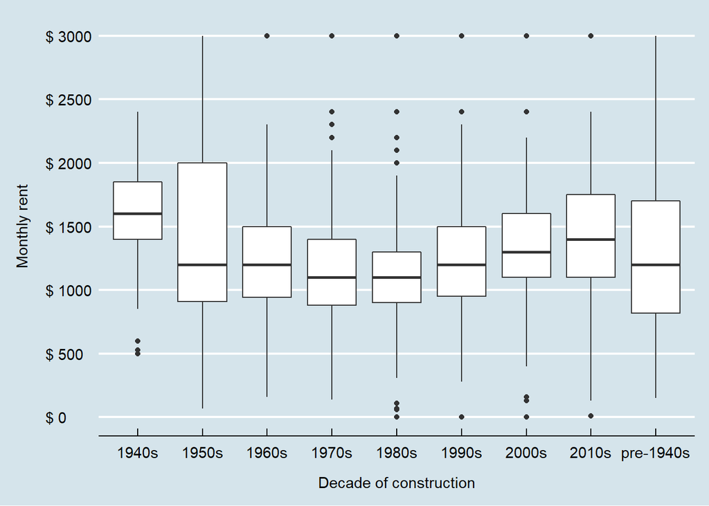

```r
options(scipen = 999)
ggplot(hh_data_a3, aes(x = BLDG_AGE_dec, y = RNTP)) +
  geom_boxplot() +
  theme_economist() +
  theme(axis.text.x = element_text(angle = 0)) +
  scale_x_discrete(name = "\nDecade of construction") +
  scale_y_continuous(name = "Monthly rent\n",
                     breaks = seq(0, 3000, by = 500),
                     labels = paste("$",
                                    prettyNum(seq(0, 3000, by = 500))))
```

As seen above, households built in the 1950s have the widest interquartile range of monthly rent, while households built in the 1940s pay the highest median rents, followed by households built within the last 20 years. As could possibly be inferred from the household income trends above, households built in the 1970s and 1980s pay the lowest median rents.

### ANOVA test seven: NP and BLDG_AGE_dec

Test of relationship between household size and decade of construction.

```r
anova7 <- aov(NP ~ BLDG_AGE_dec, data = hh_data_a3)

summary(anova7)
```

```
##                Df Sum Sq Mean Sq F value           Pr(>F)
## BLDG_AGE_dec    8    262   32.73   9.085 0.00000000000192 ***
## Residuals    3789  13648    3.60
## ---
## Signif. codes:  0 '***' 0.001 '**' 0.01 '*' 0.05 '.' 0.1 ' ' 1
```

```r
differences7 <- TukeyHSD(anova7)

as_tibble(cbind(pair = row.names(differences7$BLDG_AGE_dec),
                differences7$BLDG_AGE_dec))
```

```
## # A tibble: 36 x 5
##    pair          diff             lwr             upr            `p adj`
##    <chr>         <chr>            <chr>           <chr>          <chr>
##  1 1950s-1940s   0.7163636363636~ -0.21214351891~ 1.64487079164~ 0.287109926835~
##  2 1960s-1940s   -0.104989747095~ -0.97749018126~ 0.76751068707~ 0.999989563175~
##  3 1970s-1940s   0.6676136363636~ -0.16005475374~ 1.49528202647~ 0.230446519326~
##  4 1980s-1940s   0.5402926604447~ -0.28116782136~ 1.36175314225~ 0.514344605872~
##  5 1990s-1940s   0.2837156612857~ -0.54385069926~ 1.11128202183~ 0.979168625387~
##  6 2000s-1940s   0.6119733924612  -0.21702520792~ 1.44097199284~ 0.347676458078~
##  7 2010s-1940s   0.0414824663453~ -0.79173532814~ 0.87470026083~ 0.999999990156~
##  8 pre-1940s-19~ 0.2448742746615~ -0.75508695346~ 1.24483550279~ 0.997834970494~
##  9 1960s-1950s   -0.821353383458~ -1.42279782572~ -0.2199089411~ 0.000774815457~
## 10 1970s-1950s   -0.048749999999~ -0.58308451458~ 0.48558451458~ 0.999998804127~
## # ... with 26 more rows
```

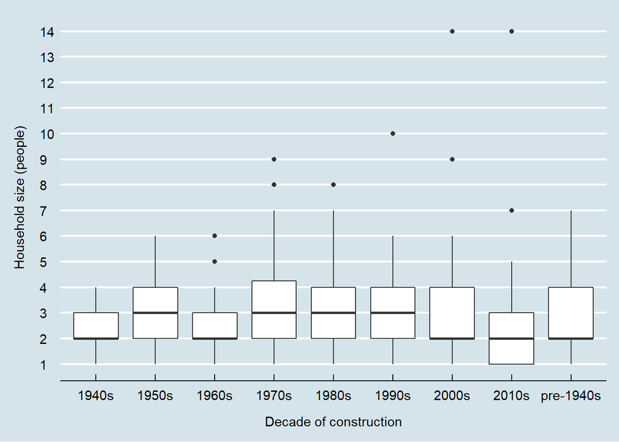

```r
ggplot(hh_data_a3, aes(x = BLDG_AGE_dec, y = NP)) +
  geom_boxplot() +
  theme_economist() +
  theme(axis.text.x = element_text(angle = 0)) +
  scale_x_discrete(name = "\nDecade of construction") +
  scale_y_continuous(name = "Household size (people)\n",
                     breaks = seq(0, 15, by = 1),
                     labels = paste(prettyNum(seq(0, 15, by = 1))))
```

This box plot shows that the variation of household size by decade of construction, while significant, is small - all categories have a median value of either 2 or 3 people, and almost all interquartile ranges are between 2 and 4 people.

One notable exception is households built in the 2010s. These have a median size of 2 people, and interquartile range of between 1 and 3 people (not to mention an absolute maximum value of 14 people) - this may be indicative of a recent trend toward building smaller housing units, as well as possibly student housing or other dormitory-style spaces.

### ANOVA test eight: BDSP and BLDG_AGE_dec

Test of relationship between bedrooms per household and decade of construction.

```r
anova8 <- aov(BDSP ~ BLDG_AGE_dec, data = hh_data_a3)

summary(anova8)
```

```
##                Df Sum Sq Mean Sq F value         Pr(>F)
## BLDG_AGE_dec    8     66   8.197   7.562 0.000000000453 ***
## Residuals    3789   4107   1.084
## ---
## Signif. codes:  0 '***' 0.001 '**' 0.01 '*' 0.05 '.' 0.1 ' ' 1
```

In this test we see a low p-value (<4.53e-10), indicating that there is a statistically significant relationship between annual bedrooms per household and the age of building construction. Again, the Tukey’s HSD test and accompanying box plot.

```r
differences8 <- TukeyHSD(anova8)

as_tibble(cbind(pair = row.names(differences8$BLDG_AGE_dec),
                differences8$BLDG_AGE_dec))
```

```
## # A tibble: 36 x 5
##    pair          diff              lwr             upr            `p adj`
##    <chr>         <chr>             <chr>           <chr>          <chr>
##  1 1950s-1940s   0.018787878787931 -0.49056879453~ 0.52814455211~ 0.99999999909~
##  2 1960s-1940s   -0.0853725222145~ -0.56400525659~ 0.39326021216~ 0.99978733452~
##  3 1970s-1940s   -0.1186079545454~ -0.57264690879~ 0.33543099970~ 0.99658940313~
##  4 1980s-1940s   -0.16202327457076 -0.61265671977~ 0.28861017063~ 0.97200436216~
##  5 1990s-1940s   -0.1813367318039~ -0.63531971509~ 0.27264625149~ 0.94770028478~
##  6 2000s-1940s   0.03976348854401~ -0.41500518704~ 0.49453216413~ 0.99999914443~
##  7 2010s-1940s   -0.3989695861724~ -0.85605281007~ 0.05811363773~ 0.14483209025~
##  8 pre-1940s-19~ -0.0098646034815~ -0.55841926104~ 0.53869005408~ 0.99999999999~
##  9 1960s-1950s   -0.1041604010025~ -0.43409834338~ 0.22577754137~ 0.98772183352~
## 10 1970s-1950s   -0.1373958333333~ -0.43051888493~ 0.15572721827~ 0.87614555130~
## # ... with 26 more rows
```

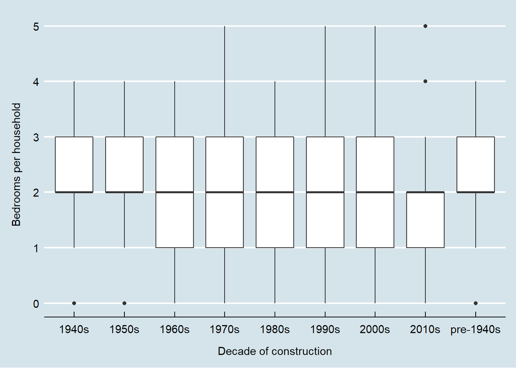

```r
ggplot(hh_data_a3, aes(x = BLDG_AGE_dec, y = BDSP)) +
  geom_boxplot() +
  theme_economist() +
  theme(axis.text.x = element_text(angle = 0)) +
  scale_x_discrete(name = "\nDecade of construction") +
  scale_y_continuous(name = "Bedrooms per household\n",
                     breaks = seq(0, 6, by = 1),
                     labels = paste(prettyNum(seq(0, 6, by = 1))))
```

This box plot shows that again while the relationship between bedrooms per household and decade of construction is statistically significant, the magnitude of the relationship is small - in fact, all categories have a median value 2 bedrooms, and most interquartile ranges are between 1 and 3. This is not surprising given the narrow overall range in the data (0 to 5).